# Analysis to Address Recall Bias Associated with Self-Reporting of Behavior

Preview

Hiroki Kato

2022-07-01

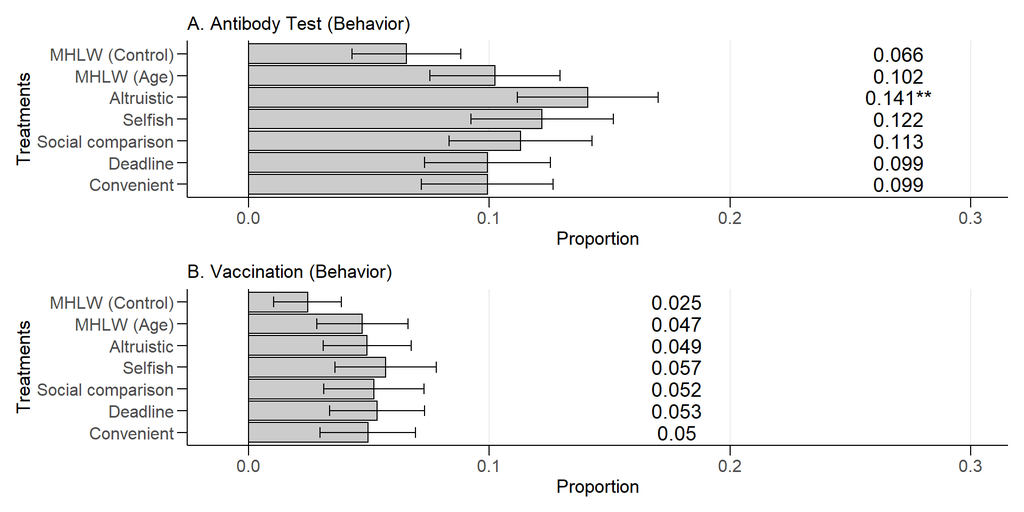

Effect of Text-Based Nudges on Behavior among Men for whom Coupons are Automatically Distributed in FY 2019 (N = 881). Data source: new wave 2 selection data. Note: Numbers in the figure indicate the proportion of each group. Error bars indicate standard error of the mean. Asterisks are p-values for t-tests of the difference in means from the MHLW message group: * p < 0.1, ** p < 0.05, *** p < 0.01.

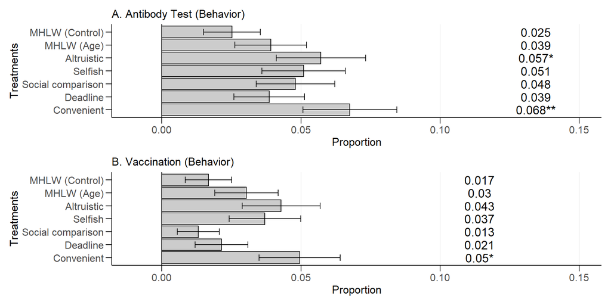

Effect of Text-Based Nudges on Behaviors among Men Who Needed Costly Procedures to Receive Coupons in FY 2019 (N = 1,578). Data source: new wave 2 selection data. Note: Numbers in the figure indicate the proportion of each group. Error bars indicate standard error of the mean. Asterisks are p-values for t-tests of the difference in means from the MHLW message group: * p < 0.1, ** p < 0.05, *** p < 0.01.

2019年度にクーポン券を自動的に受け取った男性に限定して、 我々は各介入群の抗体検査受検率（パネルA）とワクチン接種率（パネルB）を 図@ref(fig:act2-coupon1-ttest)に示した。 その結果、利他強調メッセージは厚労省メッセージよりも抗体検査受検率が高い。 厚労省メッセージの抗体検査受検率は6.6%であるのに対し、 利他強調メッセージの抗体検査受検率は14.1%である。 したがって、厚労省メッセージと比較して、 利他強調メッセージは抗体検査の受検率を7.5%ポイント高めていて、 これは統計的に5%水準で有意である。 この効果の規模は本論の結果と一致している。 また、利他強調メッセージのワクチン接種率に対する効果は統計的に非有意である。

2019年度にクーポン券を受け取るためにはコストのかかる手続きが必要な男性に限定して、 我々は各介入群の抗体検査受検率（パネルA）とワクチン接種率（パネルB）を 図@ref(fig:act2-coupon0-ttest)に示した。 その結果、利他強調メッセージと低コストメッセージは厚労省メッセージよりも抗体検査の受検率を高めていて、 低コストメッセージのみが厚労省メッセージよりもワクチン接種率を高めている。 厚労省メッセージの抗体検査の受検率は2.5%であり、 利他強調メッセージと低コストメッセージの受検率はそれぞれ5.7%と6.8%である。 したがって、利他強調メッセージと低コストメッセージの抗体検査の受検率に対する効果はそれぞれ 3.2%ポイント・4.3%ポイントであり、 これらは統計的に有意である。 また、厚労省メッセージのワクチン接種率は1.7%であり、 低コストメッセージの受検率は5%である。 したがって、低コストメッセージのワクチン接種率に対する効果は3.3%ポイントであり、 これは統計的に10%水準で有意である。

Linear Probability Model of Behaviors Using New Wave 2 Selection Data

Antibody Test

Vaccination

MHLW (Age)

0.010

0.012

(0.017)

(0.014)

Altruistic

0.028

0.023

(0.019)

(0.016)

Selfish

0.020

0.019

(0.018)

(0.015)

Social comparison

0.020

－0.005

(0.018)

(0.011)

Deadline

0.013

0.005

(0.016)

(0.013)

Convenient

0.041**

0.031*

(0.020)

(0.017)

Coupon

0.019

－0.014

(0.028)

(0.021)

Coupon×Age expression

0.025

0.010

(0.038)

(0.027)

Coupon×Altruistic

0.046

0.000

(0.041)

(0.028)

Coupon×Selfish

0.042

0.015

(0.041)

(0.029)

Coupon×Social comparison

0.031

0.032

(0.041)

(0.027)

Coupon×Valid date

0.019

0.023

(0.038)

(0.027)

Coupon×Low-cost

－0.006

－0.006

(0.040)

(0.029)

Num.Obs.

2459

2459

R2

0.096

0.052

R2 Adj.

0.086

0.042

Covariates

X

X

* p < 0.1, ** p < 0.05, *** p < 0.01

Note: * p < 0.1, ** p < 0.05, *** p < 0.01. We use robust standard errors. We also control for covariates obtained in wave 1 and 2. The list of covariates is presented in Table @ref(tab:covlist).

Effects of Text-Based Nudges on Behaviors Using Linear Probability Model Estimates (Data: New Wave 2 Selection Data)

| How to get coupons | Text-based nudges | Antibody Test estimate | Antibody Test std.error | Antibody Test p.value | Vaccination estimate | Vaccination std.error | Vaccination p.value |
| --- | --- | --- | --- | --- | --- | --- | --- |
| Costly procedure | MHLW (Age) | 0.010 | 0.017 | 0.530 | 0.012 | 0.014 | 0.404 |
|  | Altruistic | 0.028 | 0.019 | 0.146 | 0.023 | 0.016 | 0.152 |
|  | Selfish | 0.020 | 0.018 | 0.270 | 0.019 | 0.015 | 0.213 |
|  | Social comparison | 0.020 | 0.018 | 0.275 | －0.005 | 0.011 | 0.668 |
|  | Deadline | 0.013 | 0.016 | 0.436 | 0.005 | 0.013 | 0.688 |
|  | Convenient | 0.041 | 0.020 | 0.039 | 0.031 | 0.017 | 0.065 |
| Automatic receiving | MHLW (Age) | 0.035 | 0.035 | 0.308 | 0.022 | 0.023 | 0.354 |
|  | Altruistic | 0.074 | 0.036 | 0.043 | 0.023 | 0.023 | 0.306 |
|  | Selfish | 0.062 | 0.037 | 0.088 | 0.034 | 0.025 | 0.175 |
|  | Social comparison | 0.051 | 0.037 | 0.166 | 0.027 | 0.025 | 0.278 |
|  | Deadline | 0.032 | 0.034 | 0.347 | 0.028 | 0.024 | 0.246 |
|  | Convenient | 0.035 | 0.035 | 0.322 | 0.025 | 0.024 | 0.296 |

サブサンプルで推定されたナッジ・メッセージの効果は クーポン券が自動的に送付されるかどうかだけでなく、 年齢の違いの影響を受けるので、 我々はこの問題を排除するために線形確率モデルを推定した。 基本的に、二群の平均値の差の検定の結果と整合的である。 それに加えて、表@ref(tab:act2-reg-ftest)より、 2019年度にクーポン券を自動的に受け取った男性における 利己強調メッセージの抗体検査受検率に対する効果は6.2%ポイントであり、 これは統計的に10%水準で有意である。 また、2019年度にクーポン券を受け取るためにはコストのかかる手続きが必要な男性における 利他強調メッセージの抗体検査受検率に対する効果は 効果の規模が変化していないにも関わらず、統計的に非有意である。 さらに、表@ref(tab:act2-reg)より、 クーポン券を自動的に送付されるかどうかによる ナッジ・メッセージの効果の異質性は統計的に非有意である。

Movement of Antibody Test Takers (Data: New Wave 2 Selection Data)

| Text-based nudge | w/ receiving coupon automatically Antibody test | w/ receiving coupon automatically Negative test result | w/ receiving coupon automatically Vaccination | w/o receiving coupon automatically Antibody test | w/o receiving coupon automatically Negative test result | w/o receiving coupon automatically Vaccination |
| --- | --- | --- | --- | --- | --- | --- |
| MHLW (Control) | 8 | 3 | 3 | 6 | 4 | 4 |
| MHLW (Age) | 13 | 6 | 6 | 9 | 9 | 7 |
| Altruistic | 20 | 8 | 7 | 12 | 9 | 9 |
| Selfish | 15 | 7 | 7 | 11 | 8 | 8 |
| Social comparison | 13 | 7 | 6 | 11 | 5 | 3 |
| Deadline | 13 | 7 | 7 | 9 | 6 | 5 |
| Convenient | 12 | 8 | 6 | 15 | 13 | 11 |
| Fisher’s exact test (p-value) |  | 0.83 | 0.76 |  | 0.14 | 0.30 |

Note: Limiting our sample to antibody test takers, we tested the null hypothesis that the number of negative antibody tests does not differ between intervention groups with Fisher’s exact test. Also, restricting the sample to negative individuals, we tested the null hypothesis that the number of vaccinations would not differ between intervention groups with a Fisher’s exact test.

表@ref(tab:tester2-move)は各介入群の抗体検査の受検者数・陰性件数・ワクチン接種件数を示した。 本論と同様に、 クーポン券を自動的に受け取ったかどうか・介入群に関わらず、 抗体検査の結果が陰性である人のほとんどがワクチンを接種している。 よって、ワクチン接種率に対するナッジ・メッセージの効果は介入群の陰性比率に強く依存している。 事実、手続きが必要な男性に限定したとき、 低コストメッセージの陰性比率は87%($=13/15$)と非常に高い。 その結果、低コストメッセージはワクチン接種率に統計的に有意な効果を持っている。 しかしながら、介入群間の陰性比率のバラツキは統計的な誤差である可能性が高い。 我々は抗体検査の受検者をクーポン券が自動的に送付されるかどうかで分割し、 抗体検査の陰性件数が介入群間で同じであるという帰無仮説をフィッシャーの正確検定で検証した。 その結果、二つのサブサンプルで帰無仮説を棄却できない。